# Data Processes Final Project - Group 1

Artjom Poljakow, Wladyslaw Eysymontt, Mateusz Klimas, Juan Luis Ruiz-Tagle, Jorge Martín Lasaosa

20/12/2019

## Final Project Rubric

This rubric is intended to help guide expectations and increase transparency. However, it is not necessarily fully exhaustive. Make sure to read the detailed explanation on Moodle.

### Abstract (**5 points**)

- Succinctly summarizes the importance and findings of the project within the 150 word limit.

### Introduction and Related Work (**10 points**)

- Provides a clear motivation for answering a *specific* data driven question of interest (**5 points**)
- Cites 5 *relevant* pieces of relevant work (whatever format you choose is fine, including just a hyperlink) (**1 point each**)

### Exploratory Data Analysis (**20 points**)

Introduces the dataset by describing the origin (source) and structure (shape, relevant features) of the data being used (**5 points**)

   One-hundred of the 133 provisions were coded by Michael Siegel, MD, MPH, Boston University School of Public Health, with funding from the Robert Wood Johnson Foundation, Evidence for Action: Investigator-Initiated Research to Build a Culture of Health program (grant #73337), using data derived from the Thomson Reuters Westlaw legislative database. The other 33 provisions were coded using a database created by Everytown for Gun Safety and Legal Science, LLC. Shared in accordance with the Creative Commons Attribution-4.0 International License.

Creates 5 well designed and formatted graphics (**15 points**, 3 each)

- The visual uses the appropriate visual encodings based on the data type (**1 point**)
- Written interpretation of graphic is provided (**1 point**)
- Clear axis labels, titles, and legends are included, where appropriate (**1 point**)

Here we have the graphs:

1. Heatmap graph representing “Firearms Provisions in US States” dataset

[interactive chart not shown]

   This graph showcases the evolution of the number of people killed and injured in USA from 2013 to 2018. We notice quickly that the data from 2013 is far from complete, even though they have entries for all the months. 2018 has normal data from January to March, but then it finishes abruptly. We can see how the number of injured people doubles the number of killed people throughout the whole time period. If we watch closely we can perceive a tendency, some sort of cycle that repeats every year where the number of injured and killed people decreases during the winter, while it has peaks on summer.

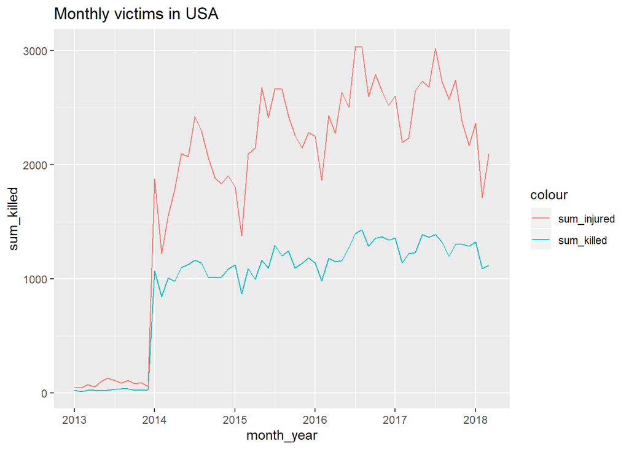

### Methods (**30 points**)

The question of interest selected from the proposal is the next one:

*Do the restrictions in a concrete State in order to purchase or use a gun affect the “gun kills/population” rate?*

In order to answer the question, “Firearms Provisions in US States” and “Gun violence” datasets are going to be joined. The percentage of policy measures is mixed with a number of kills per population rate for each year and state. Therefore, we can understand the impact of the restrictions in a concret state during the years.

The appropriate methods are employed to answer the question of interest, including: - **Strength of relationships**: Uses the appropriate technique to assess the strength of relationships amongst your variables of interest. You should include: - A formula describing how you believe your features (independent variables) are related to your outcome of interest (dependent variable) (**5 points**) - A defense of the variables included in your formula (**5 points**) - Creating the appropriate model based on your dataset (**5 points**) - **Prediction**: You must also make predictions for your outcome of interest. In doing so, you must demonstrate a clear use of: - Splitting your data into testing/training data (**2 points**) - Applying cross validation to your model (**3 points**) - Appropriately handling any missing values (**2 points**) - Appropriately using categorical variables (**3 points**) - Using a grid search to find the best parameters for you model of interest (**2 points**) - Employing the algorithm of interest (**3 points**)

### Results (**20 points**)

You must provide a clear interpretation of your statistical and machine learning results, including at least **one visual or table** for each. - **Strengths of relationships**: For the features you included in your model, you must describe the strength (significance) and magnitude of the relationships. This can be presented in a table or chart, and pertinent observations should be described in the text. (**10 points**) - **Predictions**: How well were you able to predict values in the dataset? You should both report appropriate metrics based on the type of outcome you’re predicting (e.g., root mean squared error v.s. accuracy), as well as a high quality visual showing the strength of your model (**10 points**)

### Discussion and Future Work (**10 points**)

Based on *specific observations* from the results section, the report clearly provides: - An analysis of the real world implications of the results, at least one full paragraph (**5 points**) - Clear suggestion for directions of future research, at least one full paragraph (**5 points**)

### Code Quality (**5 points**)

Code is well commented and structured (e.g., indented), organized across multiple different files, uses clear variable names, and runs on any computer.